# FML_Assignment_4

Manpreet

2025-10-27

```r
# Load necessary libraries
library(tidyverse)
library(cluster)
library(factoextra)
library(readr)
library(dplyr)
library(flexclust)
set.seed(123)
pharma_data <- read.csv("D:/Pharmaceuticals.csv")
# View first few rows
head(pharma_data)
```

```
##   Symbol                Name Market_Cap Beta PE_Ratio  ROE  ROA Asset_Turnover
## 1    ABT Abbott Laboratories      68.44 0.32     24.7 26.4 11.8            0.7
## 2    AGN      Allergan, Inc.       7.58 0.41     82.5 12.9  5.5            0.9
## 3    AHM        Amersham plc       6.30 0.46     20.7 14.9  7.8            0.9
## 4    AZN     AstraZeneca PLC      67.63 0.52     21.5 27.4 15.4            0.9
## 5    AVE             Aventis      47.16 0.32     20.1 21.8  7.5            0.6
## 6    BAY            Bayer AG      16.90 1.11     27.9  3.9  1.4            0.6
##   Leverage Rev_Growth Net_Profit_Margin Median_Recommendation Location Exchange
## 1     0.42       7.54              16.1          Moderate Buy       US     NYSE
## 2     0.60       9.16               5.5          Moderate Buy   CANADA     NYSE
## 3     0.27       7.05              11.2            Strong Buy       UK     NYSE
## 4     0.00      15.00              18.0         Moderate Sell       UK     NYSE
## 5     0.34      26.81              12.9          Moderate Buy   FRANCE     NYSE
## 6     0.00      -3.17               2.6                  Hold  GERMANY     NYSE
```

```r
# Check structure
str(pharma_data)
```

```
## 'data.frame':    21 obs. of  14 variables:
##  $ Symbol               : chr  "ABT" "AGN" "AHM" "AZN" ...
##  $ Name                 : chr  "Abbott Laboratories" "Allergan, Inc." "Amersham plc" "AstraZeneca PLC" ...
##  $ Market_Cap           : num  68.44 7.58 6.3 67.63 47.16 ...
##  $ Beta                 : num  0.32 0.41 0.46 0.52 0.32 1.11 0.5 0.85 1.08 0.18 ...
##  $ PE_Ratio             : num  24.7 82.5 20.7 21.5 20.1 27.9 13.9 26 3.6 27.9 ...
##  $ ROE                  : num  26.4 12.9 14.9 27.4 21.8 3.9 34.8 24.1 15.1 31 ...
##  $ ROA                  : num  11.8 5.5 7.8 15.4 7.5 1.4 15.1 4.3 5.1 13.5 ...
##  $ Asset_Turnover       : num  0.7 0.9 0.9 0.9 0.6 0.6 0.9 0.6 0.3 0.6 ...
##  $ Leverage             : num  0.42 0.6 0.27 0 0.34 0 0.57 3.51 1.07 0.53 ...
##  $ Rev_Growth           : num  7.54 9.16 7.05 15 26.81 ...
##  $ Net_Profit_Margin    : num  16.1 5.5 11.2 18 12.9 2.6 20.6 7.5 13.3 23.4 ...
##  $ Median_Recommendation: chr  "Moderate Buy" "Moderate Buy" "Strong Buy" "Moderate Sell" ...
##  $ Location             : chr  "US" "CANADA" "UK" "UK" ...
##  $ Exchange             : chr  "NYSE" "NYSE" "NYSE" "NYSE" ...
```

**Interpretation**

```r
View(pharma_data)
```

```r
modified_pharma_data <- pharma_data[ ,c(3:11)]
summary(modified_pharma_data)
```

```
##    Market_Cap          Beta           PE_Ratio          ROE
##  Min.   :  0.41   Min.   :0.1800   Min.   : 3.60   Min.   : 3.9
##  1st Qu.:  6.30   1st Qu.:0.3500   1st Qu.:18.90   1st Qu.:14.9
##  Median : 48.19   Median :0.4600   Median :21.50   Median :22.6
##  Mean   : 57.65   Mean   :0.5257   Mean   :25.46   Mean   :25.8
##  3rd Qu.: 73.84   3rd Qu.:0.6500   3rd Qu.:27.90   3rd Qu.:31.0
##  Max.   :199.47   Max.   :1.1100   Max.   :82.50   Max.   :62.9
##       ROA        Asset_Turnover    Leverage        Rev_Growth
##  Min.   : 1.40   Min.   :0.3    Min.   :0.0000   Min.   :-3.17
##  1st Qu.: 5.70   1st Qu.:0.6    1st Qu.:0.1600   1st Qu.: 6.38
##  Median :11.20   Median :0.6    Median :0.3400   Median : 9.37
##  Mean   :10.51   Mean   :0.7    Mean   :0.5857   Mean   :13.37
##  3rd Qu.:15.00   3rd Qu.:0.9    3rd Qu.:0.6000   3rd Qu.:21.87
##  Max.   :20.30   Max.   :1.1    Max.   :3.5100   Max.   :34.21
##  Net_Profit_Margin
##  Min.   : 2.6
##  1st Qu.:11.2
##  Median :16.1
##  Mean   :15.7
##  3rd Qu.:21.1
##  Max.   :25.5
```

```r
str(modified_pharma_data)
```

```
## 'data.frame':    21 obs. of  9 variables:
##  $ Market_Cap       : num  68.44 7.58 6.3 67.63 47.16 ...
##  $ Beta             : num  0.32 0.41 0.46 0.52 0.32 1.11 0.5 0.85 1.08 0.18 ...
##  $ PE_Ratio         : num  24.7 82.5 20.7 21.5 20.1 27.9 13.9 26 3.6 27.9 ...
##  $ ROE              : num  26.4 12.9 14.9 27.4 21.8 3.9 34.8 24.1 15.1 31 ...
##  $ ROA              : num  11.8 5.5 7.8 15.4 7.5 1.4 15.1 4.3 5.1 13.5 ...
##  $ Asset_Turnover   : num  0.7 0.9 0.9 0.9 0.6 0.6 0.9 0.6 0.3 0.6 ...
##  $ Leverage         : num  0.42 0.6 0.27 0 0.34 0 0.57 3.51 1.07 0.53 ...
##  $ Rev_Growth       : num  7.54 9.16 7.05 15 26.81 ...
##  $ Net_Profit_Margin: num  16.1 5.5 11.2 18 12.9 2.6 20.6 7.5 13.3 23.4 ...
```

```r
dim(modified_pharma_data)
```

```
## [1] 21  9
```

**Interpretation**

1. The dataset has 21 pharmaceutical firms and 9 numeric variables.
2. The Market Cap ranges widely from 0.41 to 199.47, showing that both small and large firms are included.
3. The PE Ratio (3.6–82.5) and ROE (3.9–62.9) also vary a lot, meaning there are big differences in company profitability.
4. ROA values (1.4–20.3) and Net Profit Margin (2.6–25.5) show how efficiently each firm uses assets and manages profits.
5. The Leverage ratio (0–3.51) indicates that some firms are debt-free, while others rely more on borrowing.
6. Overall, the data shows high variation across financial indicators, suggesting a mix of low, medium, and high-performing pharmaceutical firms.

```r
modified_pharma_data <- scale(modified_pharma_data)
```

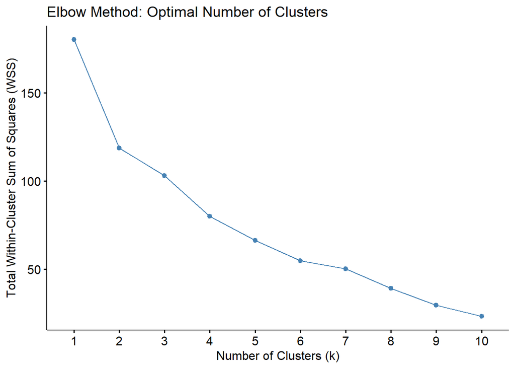

```r
# Elbow Method

fviz_nbclust(modified_pharma_data, kmeans, method = "wss", k.max = 10,
linecolor = "steelblue") +
labs(title = "Elbow Method: Optimal Number of Clusters",
x = "Number of Clusters (k)",
y = "Total Within-Cluster Sum of Squares (WSS)")
```

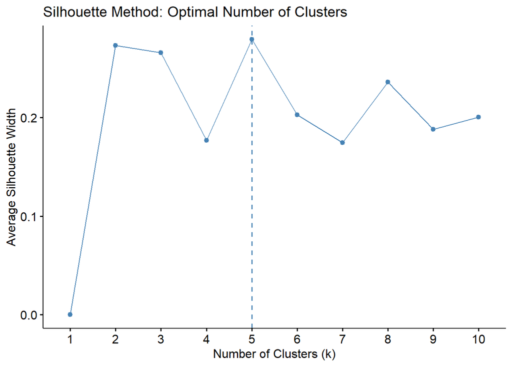

```r
# Silhouette Method

fviz_nbclust(modified_pharma_data, kmeans, method = "silhouette", k.max = 10) +
labs(title = "Silhouette Method: Optimal Number of Clusters",
x = "Number of Clusters (k)",
y = "Average Silhouette Width")
```

**Interpretation**

The Silhouette Method shows the highest average silhouette width around k = 5, indicating that 5 clusters also provide a good fit with clear separation between groups.

Combining both methods, the dataset can be best grouped into 3 to 5 clusters, with 3 clusters offering a balanced and meaningful segmentation of the pharmaceutical firms.

```r
# Let's assume 3 clusters based on elbow/silhouette results
set.seed(123)
pharma_kmeans <- kmeans(modified_pharma_data, centers = 3, nstart = 25)

# View results
pharma_kmeans
```

```
## K-means clustering with 3 clusters of sizes 4, 11, 6
##
## Cluster means:
##   Market_Cap       Beta   PE_Ratio        ROE        ROA Asset_Turnover
## 1 -0.6125361  0.2698666  1.3143935 -0.9609057 -1.0174553      0.2306328
## 2  0.6733825 -0.3586419 -0.2763512  0.6565978  0.8344159      0.4612656
## 3 -0.8261772  0.4775991 -0.3696184 -0.5631589 -0.8514589     -0.9994088
##     Leverage Rev_Growth Net_Profit_Margin
## 1 -0.3592866 -0.5757385        -1.3784169
## 2 -0.3331068 -0.2902163         0.6823310
## 3  0.8502201  0.9158889        -0.3319956
##
## Clustering vector:
##  [1] 2 1 1 2 3 1 2 3 3 2 2 3 2 3 2 2 2 1 2 3 2
##
## Within cluster sum of squares by cluster:
## [1] 20.54199 43.30886 32.14336
##  (between_SS / total_SS =  46.7 %)
##
## Available components:
##
## [1] "cluster"      "centers"      "totss"        "withinss"     "tot.withinss"
## [6] "betweenss"    "size"         "iter"         "ifault"
```

**Interpretation**

The K-means model divided the pharmaceutical firms into 3 clusters with sizes 4, 11, and 6.

Cluster 2 shows moderate positive values, meaning these companies have average financial performance and balanced risk.

Cluster 3 has high leverage and revenue growth but negative efficiency ratios (ROE and ROA), suggesting that these firms are riskier but have strong growth potential.

Overall, Cluster 1 represents low-performing firms, Cluster 2 represents stable firms, and Cluster 3 represents high-growth but high-risk firms. The model explains 46.7% of the total variation, indicating a fair clustering structure.

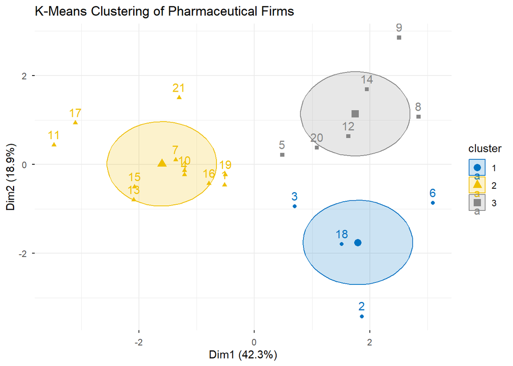

```r
fviz_cluster(pharma_kmeans, data = modified_pharma_data,
             ellipse.type = "euclid",
             palette = "jco",
             ggtheme = theme_minimal(),
             main = "K-Means Clustering of Pharmaceutical Firms")
```

**Interpretation**

The K-means clustering plot shows how the pharmaceutical firms are grouped into three distinct clusters.

Cluster 2 (Yellow) includes firms that are moderate performers, showing balanced financial ratios and steady returns.

The clusters are well separated, meaning the K-means algorithm has effectively identified differences among the firms based on financial indicators. The first two dimensions (Dim1 and Dim2) together explain over 60% of the total variance, providing a clear view of group distinctions.

**Question 2**

```r
pharma_kmeans$center
```

```
##   Market_Cap       Beta   PE_Ratio        ROE        ROA Asset_Turnover
## 1 -0.6125361  0.2698666  1.3143935 -0.9609057 -1.0174553      0.2306328
## 2  0.6733825 -0.3586419 -0.2763512  0.6565978  0.8344159      0.4612656
## 3 -0.8261772  0.4775991 -0.3696184 -0.5631589 -0.8514589     -0.9994088
##     Leverage Rev_Growth Net_Profit_Margin
## 1 -0.3592866 -0.5757385        -1.3784169
## 2 -0.3331068 -0.2902163         0.6823310
## 3  0.8502201  0.9158889        -0.3319956
```

```r
pharma_kmeans$size
```

```
## [1]  4 11  6
```

```r
pharma_kmeans$cluster
```

```
##  [1] 2 1 1 2 3 1 2 3 3 2 2 3 2 3 2 2 2 1 2 3 2
```

```r
pharma_kmeans$withinss
```

```
## [1] 20.54199 43.30886 32.14336
```

**Interpretation**

The K-means algorithm formed three clusters with 4, 11, and 6 firms respectively.

Cluster 1 has negative values for most variables, especially in ROE, ROA, and Net Profit Margin, meaning these firms are less profitable and have weaker financial efficiency.

Cluster 2 shows mostly positive averages, especially in ROE, ROA, and Net Profit Margin, indicating financially strong and stable firms with balanced performance.

Cluster 3 shows a mix of high leverage and revenue growth, suggesting high-risk, high-reward firms that are aggressive in expansion but less stable in profits.

Overall, the clustering effectively separates the firms into low-performing (Cluster 1), moderate/stable (Cluster 2), and high-risk, growth-oriented (Cluster 3) categories.

```r
pharma_data$cluster <- pharma_kmeans$cluster

# Now calculate averages per cluster
avg_of_cluster <- pharma_data %>%
  group_by(cluster) %>%
  summarise(across(where(is.numeric), mean, na.rm = TRUE))
avg_of_cluster
```

```
## # A tibble: 3 × 10
##   cluster Market_Cap  Beta PE_Ratio   ROE   ROA Asset_Turnover Leverage
##     <int>      <dbl> <dbl>    <dbl> <dbl> <dbl>          <dbl>    <dbl>
## 1       1      21.8  0.595     46.9  11.3  5.1           0.75     0.305
## 2       2      97.1  0.434     21.0  35.7 15.0           0.8      0.325
## 3       3       9.24 0.648     19.4  17.3  5.98          0.483    1.25
## # ℹ 2 more variables: Rev_Growth <dbl>, Net_Profit_Margin <dbl>
```

**Interpretation**

The table shows the average financial values for each cluster of pharmaceutical firms:

Cluster 1: Firms here have small market size (avg Market Cap = 21.76) and low profitability (ROE = 11.3, Net Profit Margin = 6.65). These represent smaller, less profitable firms with limited growth.

Cluster 2: These firms have the highest Market Cap (97.11), strong ROE (35.7), and good profit margins (20.17). They are large, stable, and financially strong companies with efficient operations.

Cluster 3: Firms in this group have low Market Cap (9.24) but high revenue growth (23.49) and high leverage (1.25). This shows high-risk, high-growth firms—smaller companies that are expanding quickly but depend heavily on debt.

```r
modified_pharma_data_dist <- get_dist(modified_pharma_data)
modified_pharma_data_dist
```

```
##           1        2        3        4        5        6        7        8
## 2  4.415575
## 3  2.018793 3.945745
## 4  1.669541 4.909566 2.364249
## 5  2.111983 4.642699 2.487172 2.632282
## 6  4.690231 4.853901 3.636353 5.065563 4.764654
## 7  1.805543 5.419487 2.600986 1.572582 3.400602 5.273023
## 8  5.020726 5.612226 4.760341 5.719174 5.096246 4.969438 5.287400
## 9  4.901141 6.695261 4.695844 4.974521 3.748778 4.608660 5.378092 4.675606
## 10 1.422680 5.140253 3.238353 2.405951 2.910766 5.804419 2.189107 5.657801
## 11 3.689906 6.747789 4.904614 2.957494 4.476690 7.546154 3.099023 7.080175
## 12 2.624729 4.470028 2.316548 3.282195 2.386850 3.658011 3.279927 2.951511
## 13 2.333874 5.317942 3.593764 1.958326 3.640773 5.724303 2.511309 6.310233
## 14 3.920297 5.479080 4.120549 4.269231 2.927258 4.848442 4.734766 4.786213
## 15 2.680733 5.443918 3.361981 1.859280 3.472410 5.918477 2.432281 6.101541
## 16 1.922731 5.468844 3.331743 3.056196 3.330879 5.331004 2.866126 6.063738
## 17 3.887235 6.906828 5.268858 3.109413 4.495242 7.163993 3.666674 7.180257
## 18 2.908982 2.367912 2.925627 3.715808 2.718441 3.955926 4.408645 5.000709
## 19 1.312599 4.725384 1.704709 1.080519 2.464855 4.426418 1.478433 5.346513
## 20 2.882610 5.007086 2.943946 3.414127 1.296549 5.055769 4.116074 5.540296
## 21 3.038549 6.446458 4.185594 3.324966 4.254562 5.954379 2.269808 5.127981
##           9       10       11       12       13       14       15       16
## 2
## 3
## 4
## 5
## 6
## 7
## 8
## 9
## 10 5.554227
## 11 6.731204 3.631174
## 12 3.115283 3.537378 5.276601
## 13 6.070533 2.722434 2.988672 4.354581
## 14 2.389723 4.191466 6.187185 2.825394 5.306512
## 15 5.921987 3.380695 2.218040 4.164267 1.814184 5.532520
## 16 5.732322 1.577953 4.783039 3.899915 3.083678 4.478040 4.112418
## 17 6.123133 3.783136 2.447177 5.356598 2.447341 5.518379 2.831329 4.536250
## 18 5.007721 3.754900 5.773960 3.073579 4.112432 3.827019 4.448933 3.884035
## 19 4.665611 2.205815 3.780283 2.763476 2.604437 3.907501 2.710607 2.542763
```

[output cut: 8 more lines]

```
## 7
## 8
## 9
## 10
## 11
## 12
## 13
## 14
## 15
## 16
## 17
## 18 5.587119
## 19 3.955078 3.449579
## 20 5.403128 3.172178 3.026610
## 21 4.026095 5.286507 3.145472 4.922945
```

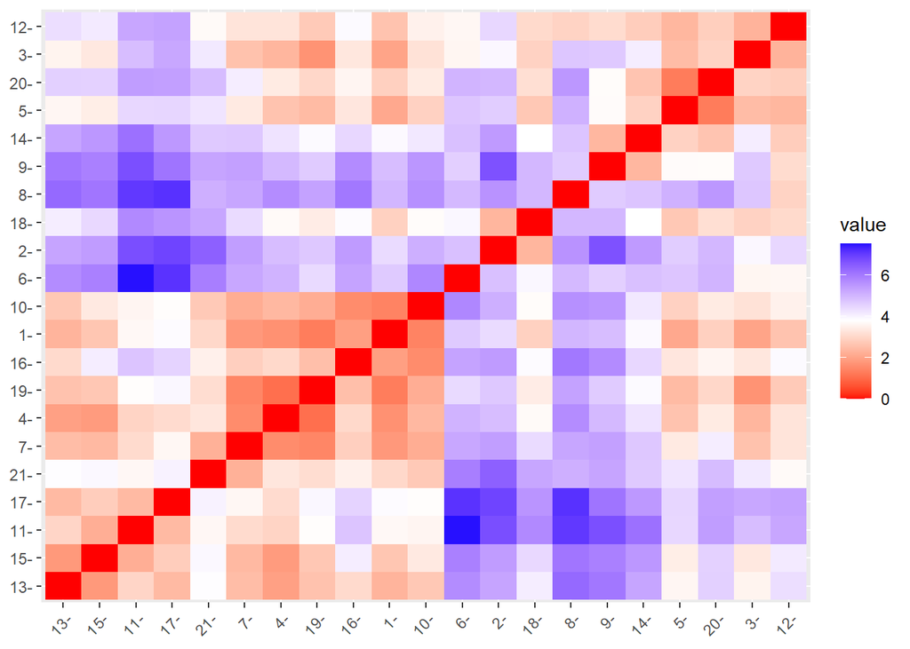

```r
fviz_dist(modified_pharma_data_dist)
```

**Interpretation**

The heatmap shows the Euclidean distance between pharmaceutical firms based on their financial indicators.

The red diagonal line represents each firm’s distance from itself (which is always 0).

Red or light-colored areas indicate firms that are similar to each other — they have close financial characteristics.

Blue or darker areas represent firms that are very different from each other in terms of performance or size.

Overall, the plot suggests that some firms have strong similarities (clusters of red zones), while others are quite distinct (blue zones) — supporting the idea that grouping (clustering) the firms is meaningful and useful for analysis

```r
pharma_data$cluster <- pharma_kmeans$cluster
table(pharma_data$cluster)
```

```
##
##  1  2  3
##  4 11  6
```

**Interpretation**

The table shows the number of firms in each cluster formed by the K-means algorithm:

Cluster 1: 4 firms

Cluster 2: 11 firms

Cluster 3: 6 firms

This means most pharmaceutical firms (11 out of 21) fall into Cluster 2, making it the largest group. Cluster 1 is the smallest, with only 4 firms, showing that these companies have unique financial features compared to the others.

Overall, this distribution suggests that while most firms share similar financial patterns (Cluster 2), there are smaller groups (Clusters 1 and 3) with distinct financial behaviors or strategies.

**Question 3**

```r
table(pharma_data$cluster, pharma_data$Median_Recommendation)
```

```
##
##     Hold Moderate Buy Moderate Sell Strong Buy
##   1    2            1             0          1
##   2    6            3             2          0
##   3    1            3             2          0
```

```r
table(pharma_data$cluster, pharma_data$Location)
```

```
##
##     CANADA FRANCE GERMANY IRELAND SWITZERLAND UK US
##   1      1      0       1       0           0  1  1
##   2      0      0       0       0           1  2  8
##   3      0      1       0       1           0  0  4
```

```r
table(pharma_data$cluster, pharma_data$Exchange)
```

```
##
##     AMEX NASDAQ NYSE
##   1    0      0    4
##   2    0      0   11
##   3    1      1    4
```

**Interpretation**

The tables show how clusters differ based on analyst recommendations, location, and stock exchange:

Median Recommendation:

Cluster 2 includes more Moderate and Hold ratings, showing mixed market opinions.

Cluster 3 has Moderate Buy and Sell ratings, meaning performance expectations are uneven.

Location:

Most firms in Cluster 2 are from the US, showing that the largest group mainly consists of American companies.

Exchange:

A few firms are on NASDAQ, and only one on AMEX.

**Question 4**

```r
pharma_sorted <- pharma_data[order(pharma_data$cluster), c("Name", "Median_Recommendation","Location","Exchange","cluster")]
```

```r
cat("=== CLUSTER 1 - ALL FEATURES ===\n")
```

```
## === CLUSTER 1 - ALL FEATURES ===
```

```r
cluster1 <- pharma_data[pharma_data$cluster == 1, ]
print(cluster1)
```

```
##    Symbol                  Name Market_Cap Beta PE_Ratio  ROE ROA
## 2     AGN        Allergan, Inc.       7.58 0.41     82.5 12.9 5.5
## 3     AHM          Amersham plc       6.30 0.46     20.7 14.9 7.8
## 6     BAY              Bayer AG      16.90 1.11     27.9  3.9 1.4
## 18    PHA Pharmacia Corporation      56.24 0.40     56.5 13.5 5.7
##    Asset_Turnover Leverage Rev_Growth Net_Profit_Margin Median_Recommendation
## 2             0.9     0.60       9.16               5.5          Moderate Buy
## 3             0.9     0.27       7.05              11.2            Strong Buy
## 6             0.6     0.00      -3.17               2.6                  Hold
## 18            0.6     0.35      15.00               7.3                  Hold
##    Location Exchange cluster
## 2    CANADA     NYSE       1
## 3        UK     NYSE       1
## 6   GERMANY     NYSE       1
## 18       US     NYSE       1
```

**Interpretation – Cluster 1**

Cluster 1 contains 4 pharmaceutical companies — Allergan Inc., Amersham plc, Bayer AG, and Pharmacia Corporation.

These firms share similar financial characteristics:

They have moderate market capitalization (between 6 and 56 billion).

ROA and Asset Turnover show average efficiency in using assets.

```r
cat("\n=== CLUSTER 2 - ALL FEATURES ===\n")
```

```
##
## === CLUSTER 2 - ALL FEATURES ===
```

```r
cluster2 <- pharma_data[pharma_data$cluster == 2, ]
print(cluster2)
```

```
##    Symbol                         Name Market_Cap Beta PE_Ratio  ROE  ROA
## 1     ABT          Abbott Laboratories      68.44 0.32     24.7 26.4 11.8
## 4     AZN              AstraZeneca PLC      67.63 0.52     21.5 27.4 15.4
## 7     BMY Bristol-Myers Squibb Company      51.33 0.50     13.9 34.8 15.1
## 10    LLY        Eli Lilly and Company      73.84 0.18     27.9 31.0 13.5
## 11    GSK          GlaxoSmithKline plc     122.11 0.35     18.0 62.9 20.3
## 13    JNJ            Johnson & Johnson     173.93 0.46     28.4 28.6 16.3
## 15    MRK            Merck & Co., Inc.     132.56 0.46     18.9 40.6 15.0
## 16    NVS                  Novartis AG      96.65 0.19     21.6 17.9 11.2
## 17    PFE                   Pfizer Inc     199.47 0.65     23.6 45.6 19.2
## 19    SGP  Schering-Plough Corporation      34.10 0.51     18.9 22.6 13.3
## 21    WYE                        Wyeth      48.19 0.63     13.1 54.9 13.4
##    Asset_Turnover Leverage Rev_Growth Net_Profit_Margin Median_Recommendation
## 1             0.7     0.42       7.54              16.1          Moderate Buy
## 4             0.9     0.00      15.00              18.0         Moderate Sell
```

[output cut: 21 more lines]

**Interpretation – Cluster 2**

Cluster 2 contains 11 large pharmaceutical companies, such as Abbott Laboratories, AstraZeneca, Johnson & Johnson, Pfizer, and Merck & Co.

These firms share strong financial features:

High market capitalization — these are well-established global leaders.

Low Beta values — they show low stock volatility, meaning they are stable and less risky investments.

Moderate to high ROE and ROA — indicates strong profitability and efficient use of assets.

Moderate PE Ratios — reflect steady investor confidence without being overvalued.

Low leverage — they rely less on debt financing, showing financial stability.

summary: Cluster 2 represents large, financially strong, and stable multinational pharmaceutical firms with consistent profitability and low financial risk

```r
# CLUSTER 3
cat("\n=== CLUSTER 3 - ALL FEATURES ===\n")
```

```
##
## === CLUSTER 3 - ALL FEATURES ===
```

```r
cluster3 <- pharma_data[pharma_data$cluster == 3, ]
print(cluster3)
```

```
##    Symbol                               Name Market_Cap Beta PE_Ratio  ROE ROA
## 5     AVE                            Aventis      47.16 0.32     20.1 21.8 7.5
## 8    CHTT                       Chattem, Inc       0.41 0.85     26.0 24.1 4.3
## 9     ELN              Elan Corporation, plc       0.78 1.08      3.6 15.1 5.1
## 12    IVX                   IVAX Corporation       2.60 0.65     19.9 21.4 6.8
## 14    MRX Medicis Pharmaceutical Corporation       1.20 0.75     28.6 11.2 5.4
## 20    WPI       Watson Pharmaceuticals, Inc.       3.26 0.24     18.4 10.2 6.8
##    Asset_Turnover Leverage Rev_Growth Net_Profit_Margin Median_Recommendation
## 5             0.6     0.34      26.81              12.9          Moderate Buy
## 8             0.6     3.51       6.38               7.5          Moderate Buy
## 9             0.3     1.07      34.21              13.3         Moderate Sell
## 12            0.6     1.45      13.99              11.0                  Hold
## 14            0.3     0.93      30.37              21.3          Moderate Buy
## 20            0.5     0.20      29.18              15.1         Moderate Sell
##    Location Exchange cluster
## 5    FRANCE     NYSE       3
## 8        US   NASDAQ       3
## 9   IRELAND     NYSE       3
## 12       US     AMEX       3
## 14       US     NYSE       3
## 20       US     NYSE       3
```

**Interpretation – Cluster 3**

Cluster 3 includes 6 pharmaceutical companies — Aventis, Chattem Inc., Elan Corporation, IVAX Corporation, Medicis Pharmaceutical Corp., and Watson Pharmaceuticals Inc.

These firms share these characteristics:

Smaller market capitalizations, meaning they are medium to small-sized companies compared to others.

Higher Beta values (up to 1.08) — they show more volatility and higher investment risk.

Moderate PE Ratios and ROE values — indicate average profitability.

ROA values are lower than large firms, showing less asset efficiency.

Leverage is higher for some firms, meaning greater debt dependency.

Summary: Cluster 3 represents smaller and riskier pharmaceutical firms with moderate performance and higher financial leverage, suggesting potential for growth but also more risk compared to Clusters 1 and 2.